# Modeling and prediction for movies

## Setup

### Load packages

```r
library(ggplot2)
library(dplyr)
library(statsr)
library(GGally)
```

### Load data

Make sure your data and R Markdown files are in the same directory. When loaded your data file will be called `movies`. Delete this note when before you submit your work.

```r
load("movies.Rdata")
```

```r
data("movies.Rdata")
```

## Part 1: Data

Data description: The data set is comprised of 651 randomly sampled movies produced and released before 2016.

Some of these variables are only there for informational purposes and do not make any sense to include in a statistical analysis. It is up to you to decide which variables are meaningful and which should be omitted. For example information in the the `actor1` through `actor5` variables was used to determine whether the movie casts an actor or actress who won a best actor or actress Oscar.

The data of the project is collected from the Rotten Tomatoes and IMDB

The data set is comprised of 651 randomly sampled movies produced and released before 2016, each row in the dataset is a movie and each column is a characteristic of a movie. Therefore, the data should allow us to generalize to the population of interest. However, there is no causation can be established because random assignment is not used in this study. In addition, potential biases are associated with non-voting or non_rating because the voting and rating are voluntary on IMDB and Rotten Tomatos website.

From common sense, we realized that many of the variables are irrelevant to the purpose of identifying the popularity of a movie. As such, we select the following variables to start our analysis.

title_type: Type of movie (Documentary, Feature Film, TV Movie) genre: Genre of movie (Action & Adventure, Comedy, Documentary, Drama, Horror, Mystery & Suspense, Other) runtime: Runtime of movie (in minutes) imdb_rating: Rating on IMDB imdb_num_votes: Number of votes on IMDB critics_rating: Categorical variable for critics rating on Rotten Tomatoes (Certified Fresh, Fresh, Rotten) critics_score: Critics score on Rotten Tomatoes audience_rating: Categorical variable for audience rating on Rotten Tomatoes (Spilled, Upright) audience_score: Audience score on Rotten Tomatoes best_pic_win: Whether or not the movie won a best picture Oscar (no, yes) best_actor_win: Whether or not one of the main actors in the movie ever won an Oscar (no, yes) - note that this is not necessarily whether the actor won an Oscar for their role in the given movie best_actress win: Whether or not one of the main actresses in the movie ever won an Oscar (no, yes) - not that this is not necessarily whether the actresses won an Oscar for their role in the given movie best_dir_win: Whether or not the director of the movie ever won an Oscar (no, yes) - not that this is not necessarily whether the director won an Oscar for the given movie

## Part 2: Research question

1.Is there any association between critics score and rating on IMDB?

2.Which website has better association with critics score?

## Part 3: Exploratory data analysis

NOTE: Insert code chunks as needed by clicking on the “Insert a new code chunk” button above. Make sure that your code is visible in the project you submit. Delete this note when before you submit your work.

To beigin with, we briefly check the data.

```r
str(movies)
```

```
## tibble [651 x 32] (S3: tbl_df/tbl/data.frame)
##  $ title           : chr [1:651] "Filly Brown" "The Dish" "Waiting for Guffman" "The Age of Innocence" ...
##  $ title_type      : Factor w/ 3 levels "Documentary",..: 2 2 2 2 2 1 2 2 1 2 ...
##  $ genre           : Factor w/ 11 levels "Action & Adventure",..: 6 6 4 6 7 5 6 6 5 6 ...
##  $ runtime         : num [1:651] 80 101 84 139 90 78 142 93 88 119 ...
##  $ mpaa_rating     : Factor w/ 6 levels "G","NC-17","PG",..: 5 4 5 3 5 6 4 5 6 6 ...
##  $ studio          : Factor w/ 211 levels "20th Century Fox",..: 91 202 167 34 13 163 147 118 88 84 ...
##  $ thtr_rel_year   : num [1:651] 2013 2001 1996 1993 2004 ...
##  $ thtr_rel_month  : num [1:651] 4 3 8 10 9 1 1 11 9 3 ...
##  $ thtr_rel_day    : num [1:651] 19 14 21 1 10 15 1 8 7 2 ...
##  $ dvd_rel_year    : num [1:651] 2013 2001 2001 2001 2005 ...
##  $ dvd_rel_month   : num [1:651] 7 8 8 11 4 4 2 3 1 8 ...
##  $ dvd_rel_day     : num [1:651] 30 28 21 6 19 20 18 2 21 14 ...
##  $ imdb_rating     : num [1:651] 5.5 7.3 7.6 7.2 5.1 7.8 7.2 5.5 7.5 6.6 ...
##  $ imdb_num_votes  : int [1:651] 899 12285 22381 35096 2386 333 5016 2272 880 12496 ...
```

[output cut: 18 more lines]

```r
summary(movies)
```

```
##     title                  title_type                 genre        runtime
##  Length:651         Documentary : 55   Drama             :305   Min.   : 39.0
##  Class :character   Feature Film:591   Comedy            : 87   1st Qu.: 92.0
##  Mode  :character   TV Movie    :  5   Action & Adventure: 65   Median :103.0
##                                        Mystery & Suspense: 59   Mean   :105.8
##                                        Documentary       : 52   3rd Qu.:115.8
##                                        Horror            : 23   Max.   :267.0
##                                        (Other)           : 60   NA's   :1
##   mpaa_rating                               studio    thtr_rel_year
##  G      : 19   Paramount Pictures              : 37   Min.   :1970
##  NC-17  :  2   Warner Bros. Pictures           : 30   1st Qu.:1990
##  PG     :118   Sony Pictures Home Entertainment: 27   Median :2000
##  PG-13  :133   Universal Pictures              : 23   Mean   :1998
##  R      :329   Warner Home Video               : 19   3rd Qu.:2007
##  Unrated: 50   (Other)                         :507   Max.   :2014
##                NA's                            :  8
##  thtr_rel_month   thtr_rel_day    dvd_rel_year  dvd_rel_month
##  Min.   : 1.00   Min.   : 1.00   Min.   :1991   Min.   : 1.000
##  1st Qu.: 4.00   1st Qu.: 7.00   1st Qu.:2001   1st Qu.: 3.000
##  Median : 7.00   Median :15.00   Median :2004   Median : 6.000
##  Mean   : 6.74   Mean   :14.42   Mean   :2004   Mean   : 6.333
##  3rd Qu.:10.00   3rd Qu.:21.00   3rd Qu.:2008   3rd Qu.: 9.000
##  Max.   :12.00   Max.   :31.00   Max.   :2015   Max.   :12.000
##                                  NA's   :8      NA's   :8
##   dvd_rel_day     imdb_rating    imdb_num_votes           critics_rating
##  Min.   : 1.00   Min.   :1.900   Min.   :   180   Certified Fresh:135
##  1st Qu.: 7.00   1st Qu.:5.900   1st Qu.:  4546   Fresh          :209
##  Median :15.00   Median :6.600   Median : 15116   Rotten         :307
##  Mean   :15.01   Mean   :6.493   Mean   : 57533
##  3rd Qu.:23.00   3rd Qu.:7.300   3rd Qu.: 58301
##  Max.   :31.00   Max.   :9.000   Max.   :893008
##  NA's   :8
##  critics_score    audience_rating audience_score  best_pic_nom best_pic_win
##  Min.   :  1.00   Spilled:275     Min.   :11.00   no :629      no :644
##  1st Qu.: 33.00   Upright:376     1st Qu.:46.00   yes: 22      yes:  7
##  Median : 61.00                   Median :65.00
##  Mean   : 57.69                   Mean   :62.36
##  3rd Qu.: 83.00                   3rd Qu.:80.00
##  Max.   :100.00                   Max.   :97.00
##
```

[output cut: 9 more lines]

```
##  Length:651         Length:651         Length:651         Length:651
##  Class :character   Class :character   Class :character   Class :character
##  Mode  :character   Mode  :character   Mode  :character   Mode  :character
##
##
##
##
##     actor5            imdb_url            rt_url
##  Length:651         Length:651         Length:651
##  Class :character   Class :character   Class :character
##  Mode  :character   Mode  :character   Mode  :character
##
##
##
##
```

```r
dim(movies)
```

```
## [1] 651  32
```

The histogram of IMDB score.

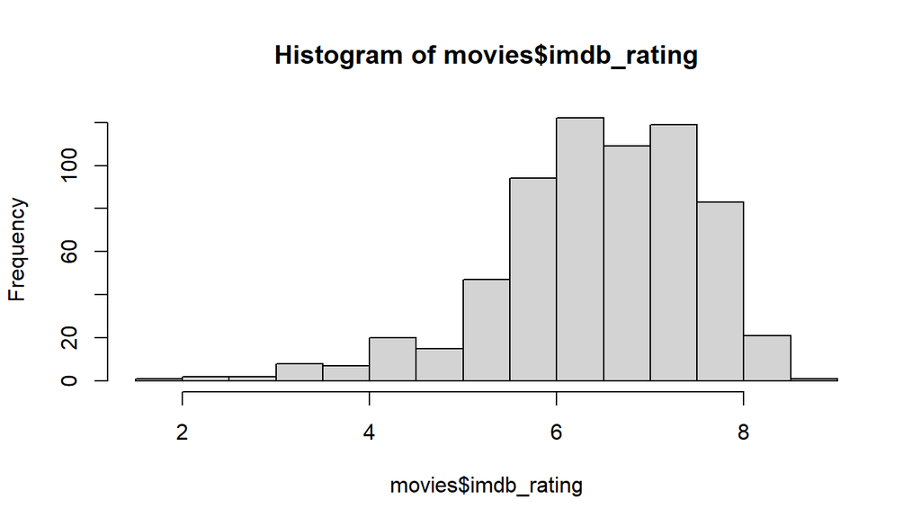

```r
hist(movies$imdb_rating)
```

The histogram of RT score.

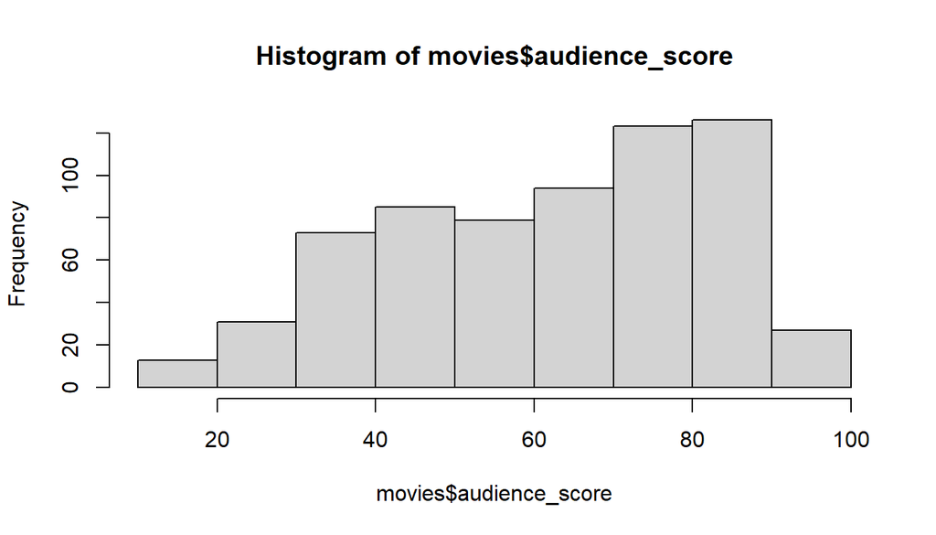

```r
hist(movies$audience_score)
```

The histogram of critic score.

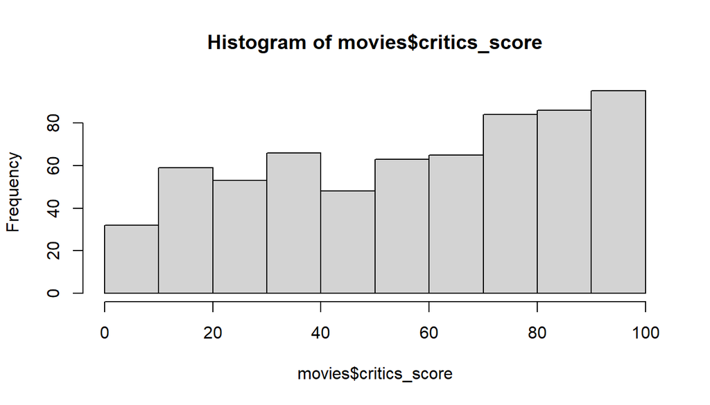

```r
hist(movies$critics_score)
```

The critics score has higher variance and lower mean.

## Part 4: Modeling

NOTE: Insert code chunks as needed by clicking on the “Insert a new code chunk” button above. Make sure that your code is visible in the project you submit. Delete this note when before you submit your work.

now we anaylze the linear association of imdb_rating, audience_score to critics_score.

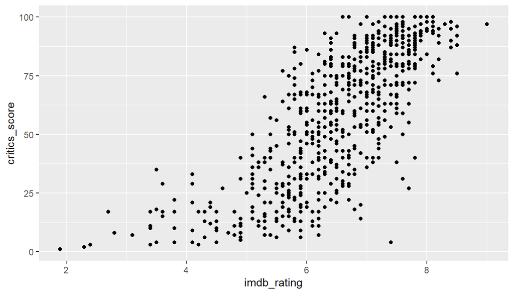

```r
ggplot(data = movies, aes(x = imdb_rating, y = critics_score)) +
  geom_point()
```

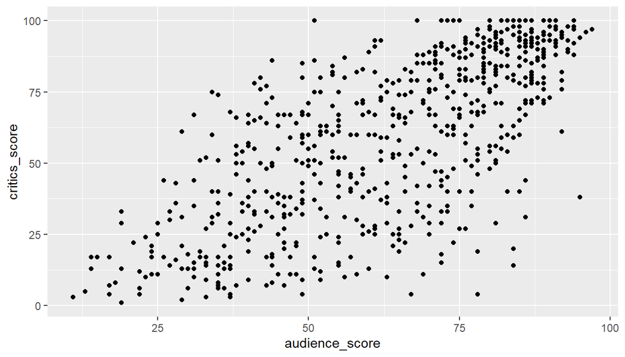

```r
ggplot(data = movies, aes(x = audience_score, y = critics_score)) +
  geom_point()
```

Seems like the imdb_rating has a high linear coefficient than audience score from RT. Then we move on to build linear model.

```r
m_full <- lm(critics_score ~ imdb_rating + audience_score, data = movies)
summary(m_full)
```

```
##
## Call:
## lm(formula = critics_score ~ imdb_rating + audience_score, data = movies)
##
## Residuals:
##     Min      1Q  Median      3Q     Max
## -72.096 -12.552   2.095  13.240  42.052
##
## Coefficients:
##                 Estimate Std. Error t value Pr(>|t|)
## (Intercept)    -62.32392    5.24444 -11.884  < 2e-16 ***
## imdb_rating     16.20148    1.30801  12.386  < 2e-16 ***
## audience_score   0.23755    0.07016   3.386 0.000753 ***
## ---
## Signif. codes:  0 '***' 0.001 '**' 0.01 '*' 0.05 '.' 0.1 ' ' 1
##
## Residual standard error: 18.16 on 648 degrees of freedom
## Multiple R-squared:  0.5925, Adjusted R-squared:  0.5912
## F-statistic: 471.1 on 2 and 648 DF,  p-value: < 2.2e-16
```

Both ratings have very small p value, however imdb rating has even smaller p value. The combination of imdb_rating and rt_rating gives a R-squared of 0.5912.

## Part 5: Prediction

NOTE: Insert code chunks as needed by clicking on the “Insert a new code chunk” button above. Make sure that your code is visible in the project you submit. Delete this note when before you submit your work.

Critics score predicted = 92

We picked another film, on 2016. RT score = 92 IMDB score = 8.0 Critics score = 80.9

Critics score predicted = 89.13

## Part 6: Conclusion

The model has a high adjusted R square, which indicates that this model could able to predict critics score based on imdb score and Rt score.